# Assignment 2 - Language Development in ASD - Making predictions

### Exercise 3) Assessing the single child

Let’s get to business. This new kiddo - Bernie - has entered your clinic. This child has to be assessed according to his group’s average and his expected development.

Bernie is one of the six kids in the test dataset, so make sure to extract that child alone for the following analysis.

You want to evaluate:

- how does the child fare in ChildMLU compared to the average TD child at each visit? Define the distance in terms of absolute difference between this Child and the average TD.
- how does the child fare compared to the model predictions at Visit 6? Is the child below or above expectations? (tip: use the predict() function on Bernie’s data only and compare the prediction with the actual performance of the child)

```r
#First we make a dataframe for Bernie
Bernie <- filter(LU_test, LU_test$SUBJ == "Bernie.")

#First, we make a dataframe with all of the TD-kids only
TD_kids <- filter(merged_data, merged_data$Diagnosis == "TD")

#Now we filter them according to visits
TD_kids_visit1 <- filter(TD_kids, TD_kids$Visit == 1)
TD_kids_visit2 <- filter(TD_kids, TD_kids$Visit == 2)
TD_kids_visit3 <- filter(TD_kids, TD_kids$Visit == 3)
TD_kids_visit4 <- filter(TD_kids, TD_kids$Visit == 4)
TD_kids_visit5 <- filter(TD_kids, TD_kids$Visit == 5)
TD_kids_visit6 <- filter(TD_kids, TD_kids$Visit == 6)

#Now we make a new column in each dataset with the mean MLU for each visit
TD_kids_visit1$mean_CHI_MLU <- mean(TD_kids_visit1$CHI_MLU)
TD_kids_visit2$mean_CHI_MLU <- mean(TD_kids_visit2$CHI_MLU)
TD_kids_visit3$mean_CHI_MLU <- mean(TD_kids_visit3$CHI_MLU)
TD_kids_visit4$mean_CHI_MLU <- mean(TD_kids_visit4$CHI_MLU)
TD_kids_visit5$mean_CHI_MLU <- mean(TD_kids_visit5$CHI_MLU)
TD_kids_visit6$mean_CHI_MLU <- mean(TD_kids_visit6$CHI_MLU)

#Now we have to make a dataset for Bernie for each visit
Bernie_visit1 <- filter(Bernie, Bernie$VISIT == "Visit1.")
Bernie_visit2 <- filter(Bernie, Bernie$VISIT == "Visit2.")
Bernie_visit3 <- filter(Bernie, Bernie$VISIT == "visit3.")
Bernie_visit4 <- filter(Bernie, Bernie$VISIT == "visit4.")
Bernie_visit5 <- filter(Bernie, Bernie$VISIT == "Visit5.")
Bernie_visit6 <- filter(Bernie, Bernie$VISIT == "Visit6.")

#We calculate the absolute difference between Bernie's MLU at each visit and the average TD-child at each visit

#Aboslute difference for visit 1
mean(TD_kids_visit1$CHI_MLU)-Bernie_visit1$CHI_MLU
```

```
## [1] -0.6693016
```

```r
#This shows that Bernie has a higher MLU than the average TD kid for visit 1

#Aboslute difference for visit 2
mean(TD_kids_visit2$CHI_MLU)-Bernie_visit2$CHI_MLU
```

```
## [1] -1.077061
```

```r
#This shows that Bernie has a higher MLU than the average TD kid for visit 2

#Aboslute difference for visit 3
mean(TD_kids_visit3$CHI_MLU)-Bernie_visit3$CHI_MLU
```

```
## [1] -1.561099
```

```r
#This shows that Bernie has a higher MLU than the average TD kid for visit 3

#Aboslute difference for visit 4
mean(TD_kids_visit4$CHI_MLU)-Bernie_visit4$CHI_MLU
```

```
## [1] -1.305728
```

```r
#This shows that Bernie has a higher MLU than the average TD kid for visit 4

#Aboslute difference for visit 5
mean(TD_kids_visit5$CHI_MLU)-Bernie_visit5$CHI_MLU
```

```
## [1] -1.549389
```

```r
#This shows that Bernie has a higher MLU than the average TD kid for visit 5

#Aboslute difference for visit 6
mean(TD_kids_visit6$CHI_MLU)-Bernie_visit6$CHI_MLU
```

```
## [1] -1.537428
```

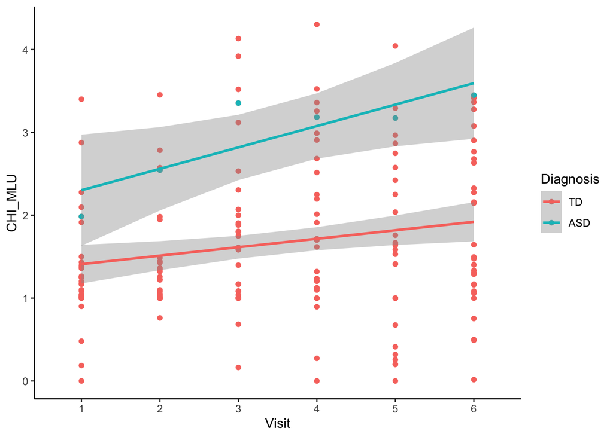

```r
#This shows that Bernie has a higher MLU than the average TD kid for visit 1

#In order to make a plot where we can compare Bernie's MLU at each visit with the average TD-child's MLU at each visit, we need to make a merged dataset where we have both Bernie's data and the average TD-children's data
Bernie <- rename(Bernie, Child.ID=SUBJ)

#We also rename the column visit
Bernie <- rename(Bernie, Visit=VISIT)

#We remove the punctuations
Bernie$Visit <- str_replace_all(Bernie$Visit, "[:punct:]", "")

#We remove all of the strings from the VISIT column so it only gives us numbers and no letters
Bernie$Visit <- str_extract(Bernie$Visit, "\\d")

#Now we take the columns that we need and make a new data frame
TD_clean <- select(TD_kids, Child.ID, Visit, Diagnosis, CHI_MLU)

#We need to make the Child.ID column into a character so it matches Bernie
TD_clean$Child.ID <- as.character(TD_clean$Child.ID)

#We take the columns we need from the Bernie dataframe
Bernie_clean <- select(Bernie, Child.ID, Visit, CHI_MLU)

#We add the column Diagnosis to Bernie (we know that he is an ASD)
Bernie_clean$Diagnosis <- "ASD"

#Now we can merge the two dataframes
Bernie_TD <- rbind(TD_clean, Bernie_clean)

#Now we make a plot because now we have both Bernie's data and all of the other data in ONE dataframe
ggplot(data = Bernie_TD, aes(x=Visit, y=CHI_MLU, group=Diagnosis, color = Diagnosis )) +
  geom_point() +
  geom_smooth(method = "lm") +
  theme_classic()
```

```r
#Now we can compare the MLU of Bernie with the average MLU of the TD kids for each visit.
```

```r
#Now we need to make predictions: how does the child fare compared to the model predictions at Visit 6? Is the child below or above expectations? (tip: use the predict() function on Bernie's data only and compare the prediction with the actual performance of the child).

#First we need to make a dataframe with all of the columns we need for Bernie. We filter Bernie's data from LU_test, token_test, and Demo_test.
LU_Bernie <- filter(LU_test, LU_test$SUBJ == "Bernie.")
Token_Bernie <- filter(token_test, token_test$SUBJ == "Bernie.")
Demo_Bernie <- filter(demo_test, demo_test$Child.ID == "Bernie")

#Now we need to rename the columns
Demo_Bernie <- rename(Demo_Bernie, SUBJ = Child.ID)
Demo_Bernie <- rename(Demo_Bernie, VISIT = Visit)

#We remove punctations and letters
Token_Bernie$VISIT <- str_extract(Token_Bernie$VISIT, "\\d")
LU_Bernie$VISIT <- str_extract(LU_Bernie$VISIT, "\\d")

Token_Bernie$VISIT <- str_replace_all(Token_Bernie$VISIT, "[:punct:]", "")
LU_Bernie$VISIT <- str_replace_all(LU_Bernie$VISIT, "[:punct:]", "")

Demo_Bernie$SUBJ <- str_replace_all(Demo_Bernie$SUBJ, "[:punct:]", "")
LU_Bernie$SUBJ <- str_replace_all(LU_Bernie$SUBJ, "[:punct:]", "")
Token_Bernie$SUBJ <- str_replace_all(Token_Bernie$SUBJ, "[:punct:]", "")

#Now we merge these dataframes into one
Bernie_all_data <- merge(LU_Bernie, Token_Bernie)
Bernie_all_data <-merge(Bernie_all_data, Demo_Bernie)

#Now we remove letters and leave the numbers in the visit column
Bernie_all_data$VISIT <- str_extract(Bernie_all_data$VISIT, "\\d")

#We rename columns and do some other necessary stuff
Bernie_all_data <- rename(Bernie_all_data, Child.ID = SUBJ, Visit = VISIT)

Bernie_all_data$Diagnosis <- "ASD"

Bernie_all_data$Diagnosis <- as.factor(Bernie_all_data$Diagnosis)

Bernie_all_data$Visit <- as.integer(Bernie_all_data$Visit)

#We select the columns we need
Bernie_all_data <- select(Bernie_all_data, Child.ID, Visit, Diagnosis, ExpressiveLangRaw, types_CHI, CHI_MLU)

#We create a subset where we have removed all of the NAs from the columns where there are NAs
Bernie_all_data <- subset(Bernie_all_data, !is.na(CHI_MLU))

Bernie_all_data <- subset(Bernie_all_data, !is.na(ExpressiveLangRaw))

#We "train" the model on the merged data
prediction_model <- lmer(CHI_MLU ~ Visit*Diagnosis*ExpressiveLangRaw*types_CHI + (1|Child.ID) + (0+Visit|Child.ID), data = merged_data)
#We test the model on Bernie's data using the predict() function
train_Bernie <- predict(prediction_model, newdata=Bernie_all_data, allow.new.levels = TRUE)

#We find the difference between the predicted values and the actual values
RMSE_bernie=rmse(Bernie_all_data$CHI_MLU, train_Bernie)

RMSE_bernie #0.40
```

```
## [1] 0.4023098
```

```r
#In order to assess how good this number is we need to calculate the standard deviation of the mean of Bernie's data
sd(Bernie_all_data$CHI_MLU) #1.04
```

```
## [1] 1.035174
```

```r
#Because the rmse-value for the predicted values using Bernie's data is much lower than the standard deviation of the mean, we can conclude that our model is good at predicting Bernie's data
```

#ANSWER The predictions for Bernie seem to be good, as the RMSE value is 0.4, which is much lower than the standard deviation of the mean (SD = 1.04), which is the NULL-model.

### OPTIONAL: Exercise 4) Model Selection via Information Criteria

Another way to reduce the bad surprises when testing a model on new data is to pay close attention to the relative information criteria between the models you are comparing. Let’s learn how to do that!

Re-create a selection of possible models explaining ChildMLU (the ones you tested for exercise 2, but now trained on the full dataset and not cross-validated).

Then try to find the best possible predictive model of ChildMLU, that is, the one that produces the lowest information criterion.

- Bonus question for the optional exercise: are information criteria correlated with cross-validated RMSE? That is, if you take AIC for Model 1, Model 2 and Model 3, do they co-vary with their cross-validated RMSE?

### OPTIONAL: Exercise 5): Using Lasso for model selection

Welcome to the last secret exercise. If you have already solved the previous exercises, and still there’s not enough for you, you can expand your expertise by learning about penalizations. Check out this tutorial: http://machinelearningmastery.com/penalized-regression-in-r/ and make sure to google what penalization is, with a focus on L1 and L2-norms. Then try them on your data!